# Bienestar subjetivo y confianza social en Europa

2026-10-31

## Introduccion

El bienestar subjetivo y la confianza interpersonal son indicadores que permiten explorar como las personas valoran su calidad de vida y sus relaciones sociales.

Este proyecto analiza datos de la European Social Survey (ESS), Round 8 (2016), mediante herramientas de analisis y visualizacion en R.

## Objetivo del proyecto

**Objetivo general**

Analizar el bienestar subjetivo y la confianza interpersonal en los paises participantes en la ESS8.

## Metodologia

- **Fuente:** European Social Survey, Round 8 (2016).
- **Base original:** 44.387 observaciones y 535 variables.
- **Variables seleccionadas:** pais, satisfaccion con la vida, felicidad, confianza interpersonal, edad y nivel educativo.
- **Procesamiento:** importacion, seleccion de variables, tratamiento de valores ausentes y creacion de grupos de edad.
- **Herramientas:** R, RStudio, R Markdown y flexdashboard.

Los resultados son descriptivos y se presentan sin ponderacion muestral.

## Resultados generales

| Indicador | Media (0-10) |
| --- | --- |
| Satisfaccion con la vida | 7.15 |
| Felicidad | 7.44 |
| Confianza interpersonal | 5.27 |

## Comparacion de indicadores

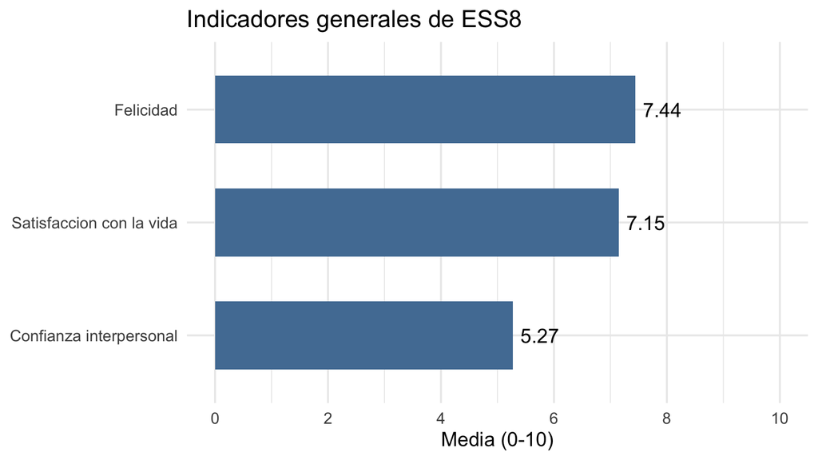

## Interpretacion de resultados

Los resultados descriptivos muestran que:

- La felicidad presenta la media mas elevada (7.44).
- La satisfaccion con la vida alcanza una media de 7.15.
- La confianza interpersonal registra una media inferior (5.27).

Estos valores describen la muestra analizada y no permiten establecer relaciones causales.

## Conclusiones

El analisis permitio explorar los niveles generales de bienestar subjetivo y confianza interpersonal en la muestra de la ESS8.

Las valoraciones de felicidad y satisfaccion con la vida fueron, en promedio, superiores a las de confianza interpersonal.

El proyecto tambien permitio aplicar procedimientos de limpieza, analisis y visualizacion de datos mediante herramientas reproducibles.

## Referencia

European Social Survey. (2016). *ESS Round 8 data, edition 2.3*.

DOI: https://doi.org/10.21338/NSD-ESS8-2016